# Analysing survival data with highly negatively skewed distribution: The Gompertz-sinh family

http://dx.doi.org/10.1080/02664760802663072

08-08-2016

Kahadawala Cooray[^1] and Malwane M.A. Ananda[^2].

# Gompertz Distribution

A distribuição Gompertz é largamente usada para descever a distribuição de morte em populações de pessoas adultas ou animais ou até mesmo em ciências atuariais.

**A função densidade de probabilidade (*f.d.p.*) é:**

> $f(x; a,b) = be^{ax}exp(-b/a(e^{ax}-1))$

**Os autores reparametrizam a *f.d.p.* da seguinte maneira:**

> $f(x; \gamma,\phi) = (\frac{\gamma}{\phi}) e^{x / \phi}exp(-\gamma(e^{x / \phi}-1))$

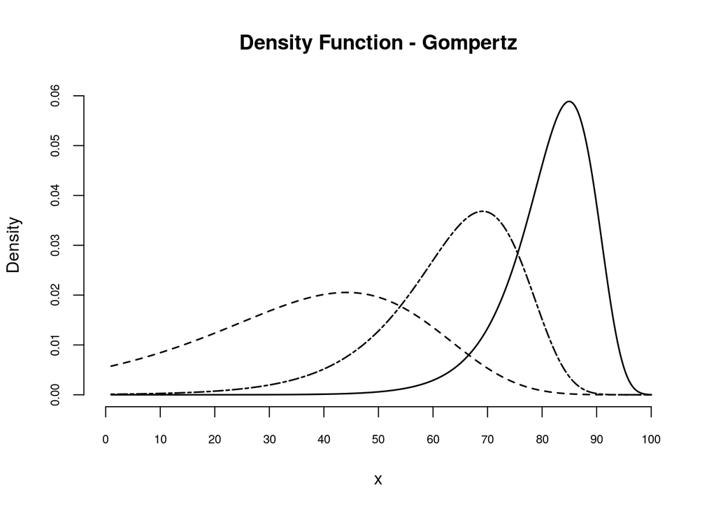

```r
##simulação para a densidade
x <- c(seq(1,100,.1))

dG <- function(x,a,b, log=FALSE){
    d2 <- numeric(length(x))
    d2 <- b*exp(a*x)*exp(-b/a*(exp(a*x) - 1))
    dens <- if(log) log(d2) else d2
    return (dens)
}
plot(sort(x),dG(sort(x),a=.16,b=.0000002),type ="l", col = 1,lwd =1.5,lty=1,axes=F,
     main ="Density Function - Gompertz",xlab = "x",, ylab='Density',xlim=c(0,100),ylim=c(0,.06))
lines(sort(x),dG(sort(x),a=.1,b=0.0001),lty=6, lwd =1.5)
lines(sort(x),dG(sort(x),a=.05,b=0.0055) ,lty=2, lwd =1.5)
#lines(sort(x),dG(sort(x),a=.1,b=0.1) ,lty=3, lwd =1.5)
axis(1, at=seq(0,100,10), cex.axis=0.7)
axis(2, at=seq(0,0.06,0.01), cex.axis=0.7)
```

**A função risco é dada pela função:**

> $h(x; a,b) = be^{ax}$

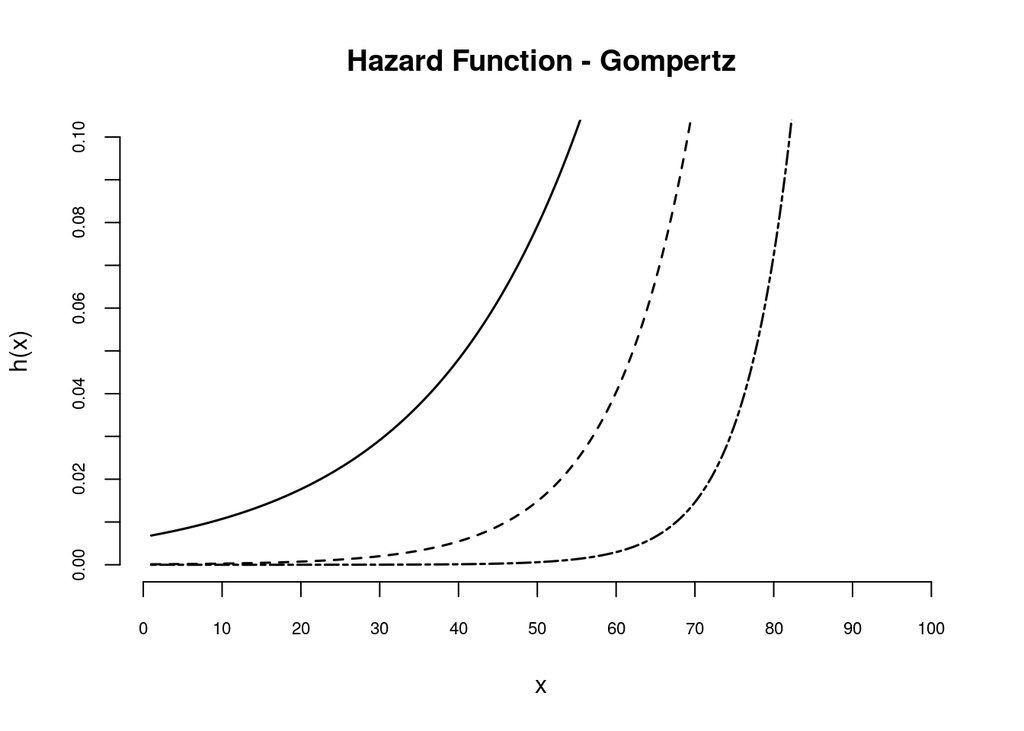

## Gompertz-sinh Distribution

A distribuição Gompertz Hiperbólica, aspresenta uma calda a esquerda mais longa e pesada do que a Gompertz apresentada anteriormente.

**Sua *f.d.p.* é dada a seguir:**

> $f(x;\alpha, \theta) = (\frac{\alpha} {\theta})e^{x / \theta} cosh(e^{x / \theta}-1)exp(-\alpha sinh(e^{x / \theta}-1))$

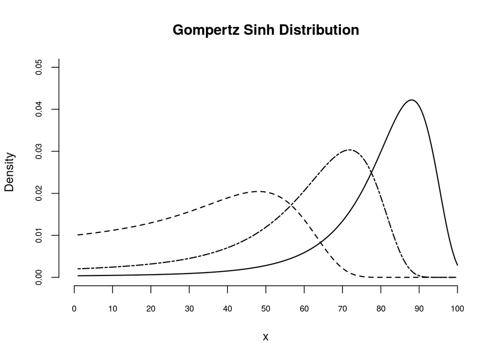

**A função risco da distribuição Gompertz Hiperbólica é:**

> $h(x; \alpha, \theta) = (\frac{\alpha} {\theta})e^{x / \theta} cosh(e^{x / \theta}-1)$

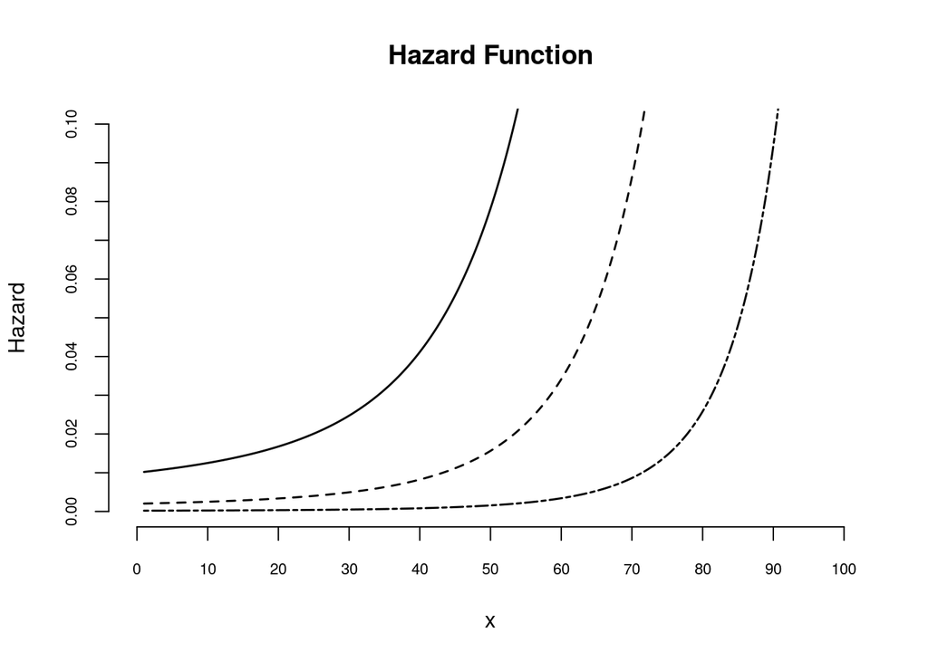

## Exponentiated Gompertz-sinh Distribution

Em geral, no mínimo três parâmetros são necessários para construir função de risco mais flexíveis.

**Sua *f.d.p.* é dada a seguir:**

> $f(x;\alpha, \beta, \theta) = (\frac{\beta \alpha} {\theta})e^{x / \theta} cosh(e^{x / \theta}-1)exp(-\alpha sinh(e^{x / \theta}-1))(1-exp(-\alpha sinh(e{x / \theta}-1)))^{\beta-1}$

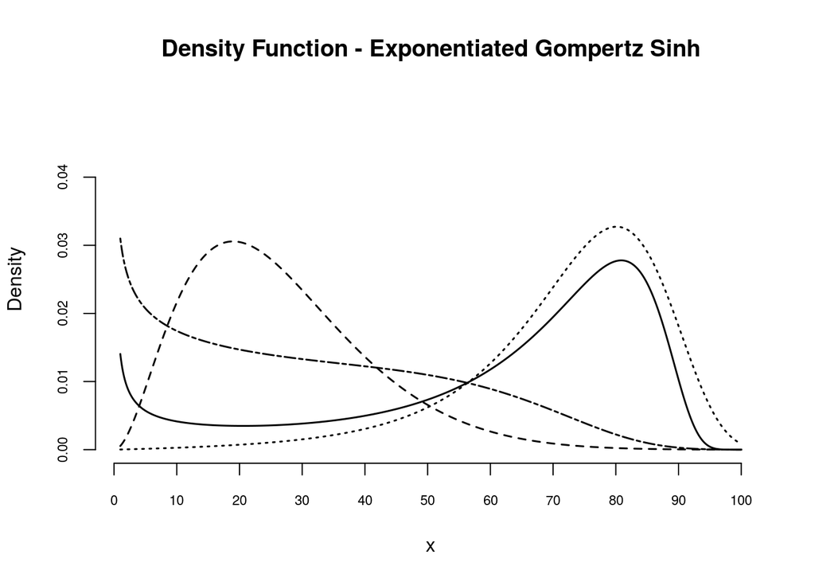

**AGORA VAMOS VER NO**

https://www.r-project.org/

[^1]: Department of Mathematics, Central Michigan University, Mount Pleasant, MI USA.
[^2]: Department of Mathematical Sciences, University of Nevada, Las Vegas, NV, USA.